# Part A. Collecting geolocated Twitter data

Load all packages here:

```r
suppressMessages(library("rtweet"))
suppressMessages(library("tidyverse"))
suppressMessages(library("maps"))
suppressMessages(library("stringr"))
suppressMessages(library("jsonlite"))
suppressMessages(library("countrycode"))
```

1. Collect a sample of geolocated tweets using your token. The geographic bounding box can span the entire globe or – probably better for the exercise – just focus on a given continent (e.g. Europe or Africa). Use the `stream_tweets` function from the `rtweet` package which we also discuss in the lab. If you e.g. use it in its form `stream_tweets(q = c(yourgeocoordinates), timeout = veryhighnumberofseconds, parse = FALSE, file_name = "yourfilename.json")`, you can let it run for some hours and it will continuously write the tweets into the JSON file name you specified. This way you can collect a sufficiently large sample, e.g. 100,000 or 200,000, of geolocated tweets. Note that because of the parse = FALSE option, the function does not return parsed data as an object in R, but just writes it into a file. Should the code break, you can restart it e.g. with another file and eventually merge all files with tweets (when combining different files with tweets, be sure to delete duplicates based on e.g. the tweet ids as the Stream API can return the same tweets in different tries). To avoid this cell with the `stream_tweets` function to run again afterwards (e.g. when knitting the file), you can either use the cache option in the chunk, as shown below, to make sure it only re-runs after you change the code, or simply comment out the code after you have downloaded all tweets and saved the file. **Please do not upload the large .json file with the tweets to GitHub!** Rather store it somewhere on your computer. (10 points)

```r
#####################
#Before running this chunk, make sure a list of 5 elements ("app", "consumer_key", "consumer_secret", "access_token" and "access_secret") called "authentication" exists in your global environment.
#####################

# Create Twitter token
#twitter_token <- create_token(app = authentication$app,
 #                             consumer_key = authentication$consumer_key,
  #                            consumer_secret = authentication$consumer_secret,
   #                           access_token = authentication$access_token,
    #                          access_secret = authentication$access_token_secret)

# Test Twitter token --> output should be: [1] "LSEnews"
lookup_users("LSEnews")$screen_name
```

```
## [1] "LSEnews"
```

```r
# Stream tweets posted in Europe (approximately) and write into a json file.
#europe_tweets <- stream_tweets(q = c(-26.126175, 34.523530, 31.002731, 71.773512), timeout = 30000000, parse = FALSE, file_name = "geolocated_tweets99.json")

#write_json(geo_tweets_parsed, "jsonjo.json")
#toJSON(geo_tweets_parsed)
```

2. Read/parse the JSON data into R with the `rtweet` functionalities. Then e.g. use the `lat_lng` function to add columns for latitude and longitude. You can delete columns that you do not need here, eventually you should have a dataframe with columns that contain the tweet id, latitude, longitude, tweet text, language, country, and country code. How many tweets did you collect? Which are the most popular hashtags? This step may take some time as well, feel free to use the cache function below to make sure you are not re-reading the file every time you compile. (7 points)

```r
###################
# Before running this chunk, make sure you know the path of your current working directory in order to know where this file is going to be saved. The path could look like this: "/Users/supermartin/thefolder" and can be changed using setwd().
###################

# Parse the tweets previously streamed into a json file into r. The result is a dataframe. Subsequently, we add the columns lat (latitude) and lng (longtitude) to the dataframe in order to be able to locate each tweets origin easier.

#Merging two json files into one
json1 <- parse_stream("geolocated_tweets.json")
json2 <- parse_stream("geolocated_tweets2.json")
geo_tweets_parsed <- rbind(json1, json2)
#write_json(jsonl, "geolocated_tweets5.json")

#geo_tweets_parsed <- parse_stream("geolocated_tweets8.json") # This parses a json file into R as a dataframe
#class(geo_tweets_parsed)
#names(geo_tweets_parsed)  # If you want to see which attributes of tweets and users you just streamed
geo_tweets_ltlng <- lat_lng(geo_tweets_parsed)

# Drop most variables of the dataframe and keep status_id, lat, lng, text, lang, country, country_code
geo_tweets_compressed <- geo_tweets_ltlng %>%
  select(status_id, lat, lng, text, lang, country, country_code)

# How many Tweets were collected?
print(paste(nrow(geo_tweets_compressed), "tweets have been collected."))
```

```
## [1] "162753 tweets have been collected."
```

```r
# Which were the most popular hashtags. The source for this is the course material from week 5, "04-twitter-streaming-api".
hashtags <- str_extract_all(geo_tweets_ltlng$text, "#[A-Za-z0-9_]+")
hashtags <- unlist(hashtags)
head(sort(table(hashtags), decreasing = TRUE))
```

```
## hashtags
##  #baskan3bindiyetisyeniata                      #free
##                        609                        601
##             #UnitedKingdom                 #foodwaste
##                        572                        515
##           #GlobalWordVigil #JeolojiMadenMuh10binKadro
##                        418                        351
```

3. Now examine the language data. Which are the most popular languages? How many unique languages did you find? Can you determine which language code corresponds to tweets whose languages could not be predicted? (5 points)

**Answer to Question 3** *The most popular language is English In total, tweets in at least 50 languages were streamed. “At least”, as the language for a number of tweets could not be predicted.* *The language code “und” symbolizes “undetermined” and hence corresponds to tweets whose languages could not be predicted. The source for Twitters language codes is: https://www.loc.gov/standards/iso639-2/ISO-639-2_utf-8.txt*

```r
# Which were the most popular languages?
languages <- str_extract_all(geo_tweets_ltlng$lang, "[A-Za-z0-9_]+")
languages <- unlist(languages)
languages <- sort(table(languages), decreasing = TRUE)
languages <- as.data.frame(languages)
head(languages)
```

```
##   languages  Freq
## 1        en 55978
## 2        tr 21848
## 3       und 20186
## 4        es 16433
## 5        fr 12818
## 6        it  5640
```

```r
print(paste("Tweets in", nrow(languages), "languages were streamed from the Twitter Streaming API."))
```

```
## [1] "Tweets in 54 languages were streamed from the Twitter Streaming API."
```

4. Produce a map of the region of the world where you collected the data that also displays the language distribution by country. For this you can build on the map plot from the lab on the Streaming API. Further information can be found in the [ggplot2 documentation](https://ggplot2.tidyverse.org/). The map could take different forms - think which one could be best at conveying the relevant information. You can check Pablo Barbera’s [Twitter profile](https://twitter.com/p_barbera) for a clue! (10 points)

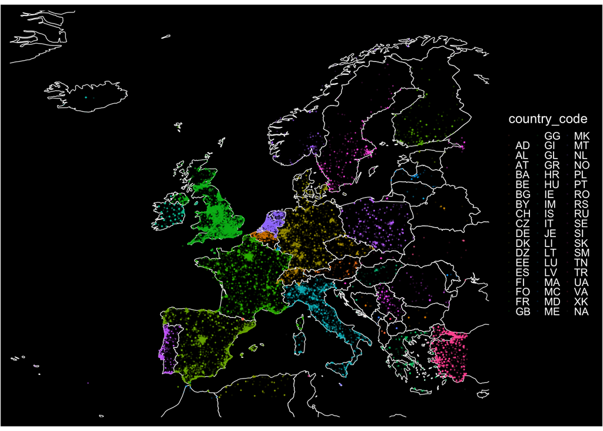

```r
## Create a data frame with the map data
map.data <- map_data("world")

## And we use ggplot2 to draw the map:
# Map base
ggplot(map.data, aes(colour = country_code)) +
    geom_map(aes(map_id = region), map = map.data, fill = "black",
    color = "white", size = 0.25) + expand_limits(x = map.data$long, y = map.data$lat) +
    coord_fixed(1.3) +

  # Limits for x and y axis
    scale_x_continuous(limits=c(-26.126175, 31.002731)) + scale_y_continuous(limits = c(34.523530, 71.773512)) +
  # Adding the dot for each tweet and specifying dot size, transparency, and colour
    geom_point(data = geo_tweets_compressed, aes(x = lng, y = lat), size = 0.001, alpha = 0.1) +

  # Removing unnecessary graph elements
      theme(axis.line = element_blank(),
            axis.text = element_blank(),
            axis.ticks = element_blank(),
            axis.title = element_blank(),
            legend.title = element_text(colour = "white"),
            legend.text = element_text(colour = "white"),
            legend.background = element_rect(fill = "black"),
            legend.box.background = element_rect(colour = NA),
            legend.key = element_rect(colour = "black"),
            legend.key.height = unit(0.01, "cm"),
            legend.key.width = unit(0.01, "cm"),
            legend.box.margin = margin(0, 0, 0, 0, unit = "pt"),
            panel.background = element_blank(),
            panel.border = element_blank(),
            panel.grid.major = element_blank(),
            panel.grid.minor = element_blank(),
            plot.background = element_rect(fill = "black"))
```

5. Which countries produced the most and the least tweets? Then, create a data frame with only four variables: `country`, `country_code`, `language`, and `n_tweets`, i.e. the number of tweets for each combination of country and language. To make it smaller, you can keep only the rows for which `n_tweets` is greater than 0! Save this data frame into a file called `part_a_country_language_distribution.csv` – we will work with it in part B. (3 points)

**Answer to Question 5** *People in the United Kingdom produced the most tweets, while people in Greenland and the Vatican produced the least tweets. This likely occurs due to market penetration of Twitter and population size of the countries.*

```r
# Creating a dataframe with three variables, `country_code`, `language`, and `n_tweets`, i.e. the number of tweets for each combination of country and language. As countries and languages only appear in the data frame if tweets with such values have been streamed, only rows where 'n_tweets' > 0 exist.
country_language_dist <- geo_tweets_compressed %>%
  select(country_code, lang) %>%
  group_by(country_code, lang) %>%
  summarise(n_tweets = n(), .groups = "drop") %>%
  drop_na()

#Add standardized country names to the country_codes as a new column
country_vector <- countrycode(country_language_dist$country_code, origin = "iso2c", destination = "country.name", custom_match = c('XK' = 'Kosovo'))
country_language_dist$country <- country_vector

#Reordering and renaming columns
country_language_dist <- country_language_dist[,c("country", "country_code", "lang", "n_tweets")]
colnames(country_language_dist) <- c("country", "country_code", "language", "n_tweets")

# Which countries produced the least tweets?
country_language_dist %>%
  group_by(country) %>%
  summarise(no_of_tweets = sum(n_tweets), .groups = "drop") %>%
  arrange(no_of_tweets)
```

```
## # A tibble: 56 x 2
##    country       no_of_tweets
##    <chr>                <int>
##  1 Greenland                1
##  2 Vatican City             1
##  3 Jersey                   2
##  4 San Marino               2
##  5 Guernsey                 6
##  6 Liechtenstein            6
##  7 Faroe Islands           10
##  8 Monaco                  10
##  9 <NA>                    20
## 10 Gibraltar               34
## # … with 46 more rows
```

```r
# Which countries produced the most tweets?
country_language_dist %>%
  group_by(country) %>%
  summarise(no_of_tweets = sum(n_tweets), .groups = "drop") %>%
  arrange(desc(no_of_tweets))
```

```
## # A tibble: 56 x 2
##    country        no_of_tweets
##    <chr>                 <int>
##  1 United Kingdom        50913
##  2 Turkey                24964
##  3 Spain                 20612
##  4 France                16014
##  5 Germany                7877
##  6 Italy                  7865
##  7 Netherlands            5975
##  8 Ireland                3769
##  9 Portugal               2928
## 10 Poland                 2789
## # … with 46 more rows
```

```r
# Write dataframe into csv file
write.csv(country_language_dist,"part_a_country_language_distribution.csv")
```